# R Notebook

```r
#install.packages("dplyr")
#install.packages("tidyverse")
#install.packages("astsa")
#install.packages("forecast")

library(dplyr)
library(tidyverse)
library(astsa)
library(forecast)
```

```r
PATH <- ""
smosh <- read.csv(paste(PATH, "smosh_market.csv", sep = ""))
head(smosh)
```

|  | Day | Month | Year | Total.Viewers | Video.1 | Video.2 | Video.3 | Video.4 | Total.Views.of.Videos.Posted.that.Week | X..Videos.Posted | Avg..Views.of.Videos.Posted.That.Week | Total.Duration.of.Videos.Posted.That.Week |
| --- | --- | --- | --- | --- | --- | --- | --- | --- | --- | --- | --- | --- |
| 1 | 25 | December | 2022 | 2787011608 | Try Not To Laugh Challenge #110 - Gauntlet w/ Our Crew! (Dec. 20 2022; 1699048, 24:05) | These Memes Destroyed Us (Who Meme'd It) (Dec. 22, 2022; 1422918, 28:13) | ; 0, | ; 0, | 3121966 | 2 | 1560983 | NA |
| 2 | 2 | January | 2023 | 2789909808 | Eat It Or Yeet It: Cast vs. Crew! (Dec. 27 2022; 896884, 25:49) | Beopardy 2022 Marathon (Dec. 29 2022; 789801, 04:57:38) | ; 0, | ; 0, | 1686685 | 2 | 843343 | NA |
| 3 | 10 | January | 2023 | 2792792592 | Try Not To Laugh 2022 Marathon (Jan. 3 2023; 804787, 8:23:46) | Reading Unhinged Reddit Stories w/ MacDoesIt (Jan. 5 2023; 2515511, 45:47) | Eat It Or Yeet It 2022 Marathon (Jan. 10 2023; 548572, 7:10:39) | ; 0, | 3868870 | 3 | 1289623 | NA |
| 4 | 18 | January | 2023 | 2796442297 | How Much Do We Know About Spongebob? (Jan. 12 2023; 692537, 21:11) | Try Not To Laugh Challenge #111 (Jan. 17 2023; 2693844, 26:05) | ; 0, | ; 0, | 3386381 | 2 | 1693191 | NA |
| 5 | 26 | January | 2023 | 2800576231 | Short Kings Rank Short Kings (Jan. 19 2023; 684072, 36:59) | Filipino Food Taste Test (Eat It or Yeet It) (Jan. 24 2023; 1970618, 25:04) | Can I Work A Real Job? (Jan. 26 2023; 864940, 30:33) | ; 0, | 3519630 | 3 | 1173210 | NA |
| 6 | 3 | February | 2023 | 2805812495 | Try Not To Laugh Challenge #112 (Jan. 31 2023; 1457075, 19:58) | We Try The TikTok Candle Challenge… and MORE! \| The Challenge Pit (Feb. 2 2023; 818879, 22:07) | ; 0, | ; 0, | 2275954 | 2 | 1137977 | NA |

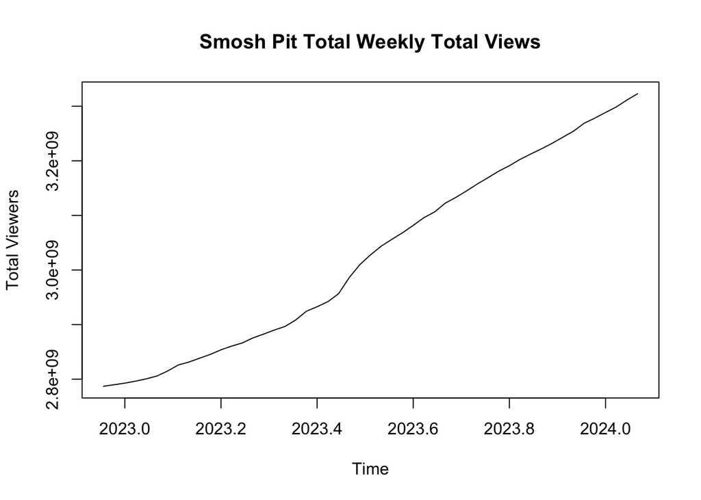

```r
smosh <- smosh %>% rename("Total Viewers" = "Total.Viewers")
sm <- ts(smosh["Total Viewers"], start = c(2022, 44), frequency = 45)
plot(sm, main = "Smosh Pit Total Weekly Total Views")
```

- Non-stationary in mean
- Dataframe only about a year, likely won’t track seasonality (if any) and unlikely due to nature of channel
- Mild viewership jump around June 2023 (steeper slope after jump?)

```r
growth <- diff(sm)

which.max(growth)
```

```
## [1] 23
```

```r
growth[23]
```

```
## [1] 29457404
```

```r
which.min(growth)
```

```
## [1] 2
```

```r
growth[2]
```

```
## [1] 2882784
```

```r
# 24 and 25 (now 23 and 24) have most significant increases in viewership
# (Anthony returns - 24th Anthony specific videos (in title))
```

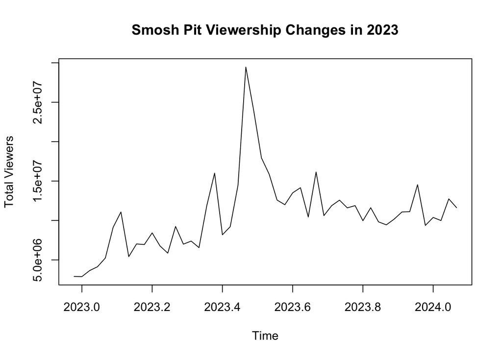

```r
plot(growth, type = "l", main = "Smosh Pit Viewership Changes in 2023")
```

```r
# 5 noticeable peaks (7, 18/19, 23/24, 32, 45)
# post big peak - different mean, variance pretty constant aside from peaks
```

- Mean more stationary…how significant is difference after massive peak
- Variance changes: some kind of seasonality or caused by outside events (like major peak)?? - appear about eqidistant of eachother

```r
# roa = return of Anthony

pre_roa <- growth[1:22]
post_roa <- growth[24:50]
mean(pre_roa)
```

```
## [1] 7701073
```

```r
mean(post_roa)
```

```
## [1] 12483718
```

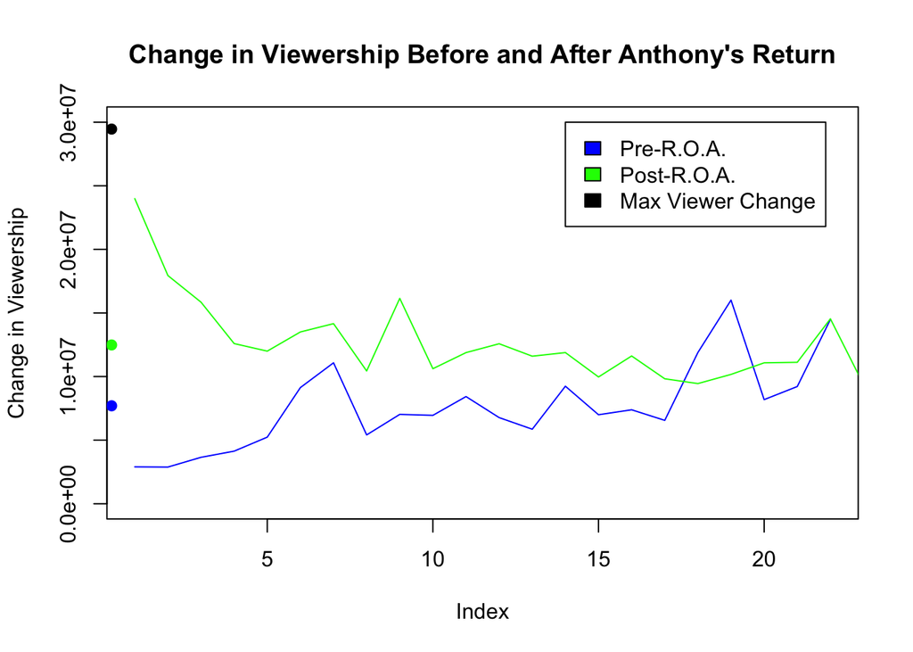

```r
plot(pre_roa, type = "l", col = "blue", ylim = c(0, 30000000), ylab = "Change in Viewership", main = "Change in Viewership Before and After Anthony's Return")
lines(post_roa, type = "l", col = "green")
points(x = c(0.3, 0.3, 0.3), c(mean(pre_roa), mean(post_roa), max(growth)), col = c("blue", "green", "black"), pch = 19)
legend(14, 30000000, legend = c("Pre-R.O.A.", "Post-R.O.A.", "Max Viewer Change"), fill = c("blue", "green", "black"))
```

Post return of Anthony has a sustained increase in viewership. Jump at end of pre-ROA period and dip at end of post-ROA period - is time series stabilizing around specific mean or residual effect of week 19 peak?

#### Finish formatting dataframe

```r
video1_len <- strcapture(".*, ([0-9]*:)*([0-9]*):([0-9]*)).*", smosh$Video.1,
                         list(hour_1 = "", minute_1 = "", second_1 = ""))
video2_len <- strcapture(".*, ([0-9]*:)*([0-9]*):([0-9]*)).*", smosh$Video.2,
                         list(hour_2 = "", minute_2 = "", second_2 = ""))
video3_len <- strcapture(".*, ([0-9]*:)*([0-9]*):([0-9]*)).*", smosh$Video.3,
                         list(hour_3 = "", minute_3 = "", second_3 = ""))
video4_len <- strcapture(".*, ([0-9]*:)*([0-9]*):([0-9]*)).*", smosh$Video.4,
                         list(hour_4 = "", minute_4 = "", second_4 = ""))

video_lengths <- cbind(video1_len, video2_len, video3_len, video4_len)
video_lengths
```

| hour_1 | minute_1 | second_1 | hour_2 | minute_2 | second_2 | hour_3 | minute_3 | second_3 | hour_4 | minute_4 | second_4 |
| --- | --- | --- | --- | --- | --- | --- | --- | --- | --- | --- | --- |
|  | 24 | 05 |  | 28 | 13 | NA | NA | NA | NA | NA | NA |
|  | 25 | 49 | 04: | 57 | 38 | NA | NA | NA | NA | NA | NA |
| 8: | 23 | 46 |  | 45 | 47 | 7: | 10 | 39 | NA | NA | NA |
|  | 21 | 11 |  | 26 | 05 | NA | NA | NA | NA | NA | NA |
|  | 36 | 59 |  | 25 | 04 |  | 30 | 33 | NA | NA | NA |
|  | 19 | 58 |  | 22 | 07 | NA | NA | NA | NA | NA | NA |
|  | 21 | 26 |  | 50 | 40 | NA | NA | NA | NA | NA | NA |
|  | 18 | 12 |  | 30 | 07 | NA | NA | NA | NA | NA | NA |
|  | 20 | 10 |  | 24 | 35 |  | 0 | 54 | NA | NA | NA |
|  | 26 | 46 |  | 24 | 25 | 1: | 13 | 45 |  | 21 | 12 |

[output cut: 41 more lines]

```r
video_lengths <-
  video_lengths %>%
  mutate(hour_1 = str_replace_all(hour_1, ":", ""),
         hour_2 = str_replace_all(hour_2, ":", ""),
         hour_3 = str_replace_all(hour_3, ":", ""),
         hour_4 = str_replace_all(hour_4, ":", ""))

video_lengths <- data.frame(sapply(video_lengths, as.integer))

h <- c("hour_1", "hour_2", "hour_3", "hour_4")
m <- c("minute_1", "minute_2", "minute_3", "minute_4")
s <- c("second_1", "second_2", "second_3", "second_4")

video_lengths <-
  video_lengths %>%
  rowwise() %>%
  mutate(hours = sum(c_across(any_of(h)), na.rm = TRUE),
         minutes = sum(c_across(any_of(m)), na.rm = TRUE),
         seconds = sum(c_across(any_of(s)), na.rm = TRUE)) %>%
  ungroup() %>% select("hours", "minutes", "seconds")
```

```r
channel_growth <- smosh %>% select(!(starts_with(("Video"))))
channel_growth["Total.Duration.of.Videos.Posted.That.Week"] <-
  video_lengths %>%
  mutate(minutes = floor(hours*60 + minutes + seconds/60)) %>% select(minutes)
```

```r
channel_growth <- channel_growth[-c(1), ]
channel_growth["Viewer Growth"] <- as.numeric(growth[, 1])

channel_growth <- channel_growth %>%
  relocate("Viewer Growth", .after = "Total Viewers") %>% rename(
    "Total Views of Videos Posted that Week" = Total.Views.of.Videos.Posted.that.Week,
    "Number Videos Posted" = X..Videos.Posted,
    "Avg. Views of Videos Posted that Week" = Avg..Views.of.Videos.Posted.That.Week,
    "Total Duration of Videos Posted that Week" = Total.Duration.of.Videos.Posted.That.Week
)

rownames(channel_growth) <- NULL
channel_growth
```

| Day | Month | Year | Total Viewers | Viewer Growth | Total Views of Videos Posted that Week | Number Videos Posted | Avg. Views of Videos Posted that Week | Total Duration of Videos Posted that Week |
| --- | --- | --- | --- | --- | --- | --- | --- | --- |
| 2 | January | 2023 | 2789909808 | 2898200 | 1686685 | 2 | 843343 | 323 |
| 10 | January | 2023 | 2792792592 | 2882784 | 3868870 | 3 | 1289623 | 980 |
| 18 | January | 2023 | 2796442297 | 3649705 | 3386381 | 2 | 1693191 | 47 |
| 26 | January | 2023 | 2800576231 | 4133934 | 3519630 | 3 | 1173210 | 92 |
| 3 | February | 2023 | 2805812495 | 5236264 | 2275954 | 2 | 1137977 | 42 |
| 11 | February | 2023 | 2814945755 | 9133260 | 3436121 | 2 | 1718061 | 72 |
| 19 | February | 2023 | 2826026147 | 11080392 | 1441645 | 2 | 720823 | 48 |
| 27 | February | 2023 | 2831436611 | 5410464 | 2620191 | 3 | 873397 | 45 |
| 7 | March | 2023 | 2838461335 | 7024724 | 6481835 | 4 | 1620459 | 146 |
| 15 | March | 2023 | 2845410880 | 6949545 | 3035189 | 3 | 1011730 | 63 |

[output cut: 40 more lines]

## First focus on viewership only

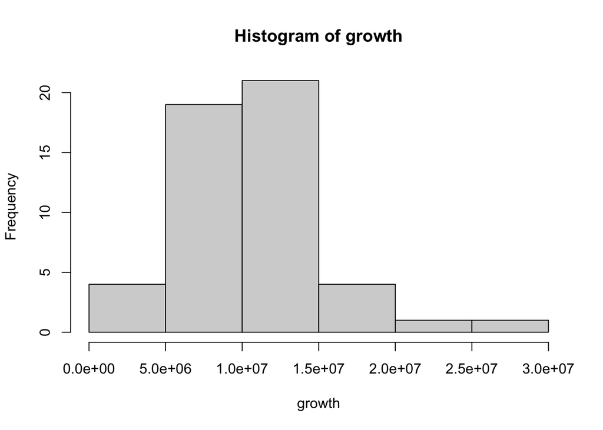

```r
hist(growth)
```

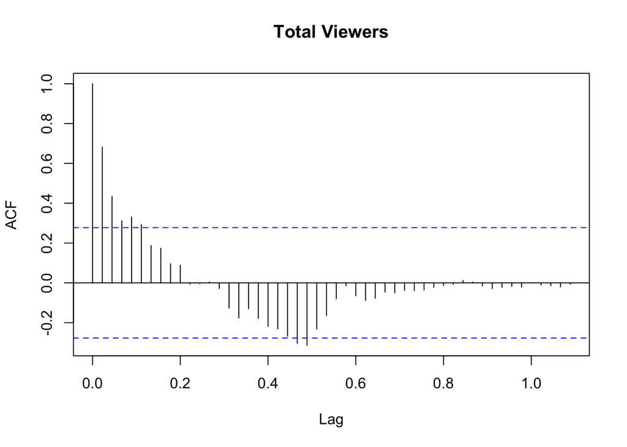

```r
acf(growth, lag.max = 50)
```

```r
# MA(2)?
```

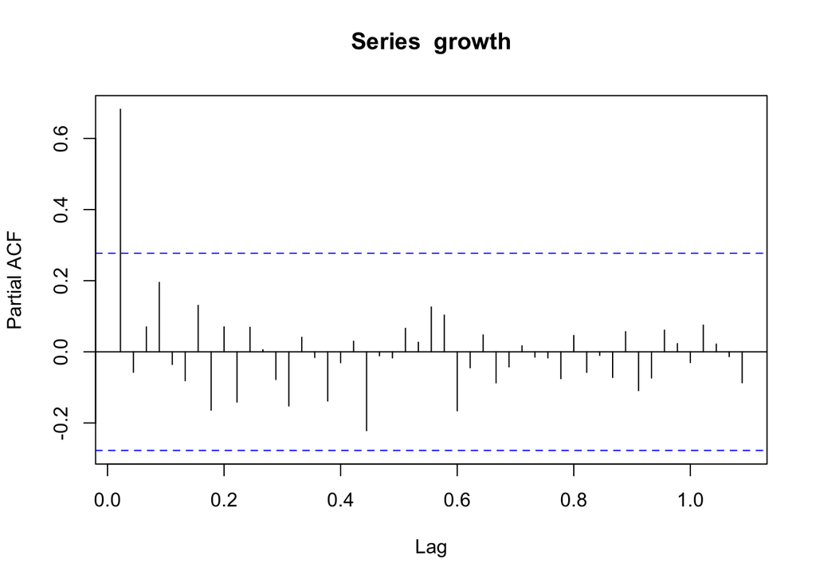

```r
pacf(growth, lag.max = 50)
```

```r
#only significant at lag 1 (AR(1))
```

Forecasting growth without intervention

```r
# train - test split
train_pre <- pre_roa[1:17]
test_pre <- pre_roa[18:22]
```

```r
# AR(1) model

#t <- 1:length(train_pre)
#noint_model <- lm(formula = pre_roa ~ t)

ar1 <- sarima(train_pre, 1, 0, 0, P = 0, D = 0, Q = 0)
```

```
## <><><><><><><><><><><><><><>
##
## Coefficients:
##           Estimate          SE t.value p.value
## ar1         0.5026      0.2171  2.3152  0.0352
## xmean 6266169.1357 900995.8430  6.9547  0.0000
##
## sigma^2 estimated as 3.724061e+12 on 15 degrees of freedom
##
## AIC = 32.15379  AICc = 32.20421  BIC = 32.30082
##
```

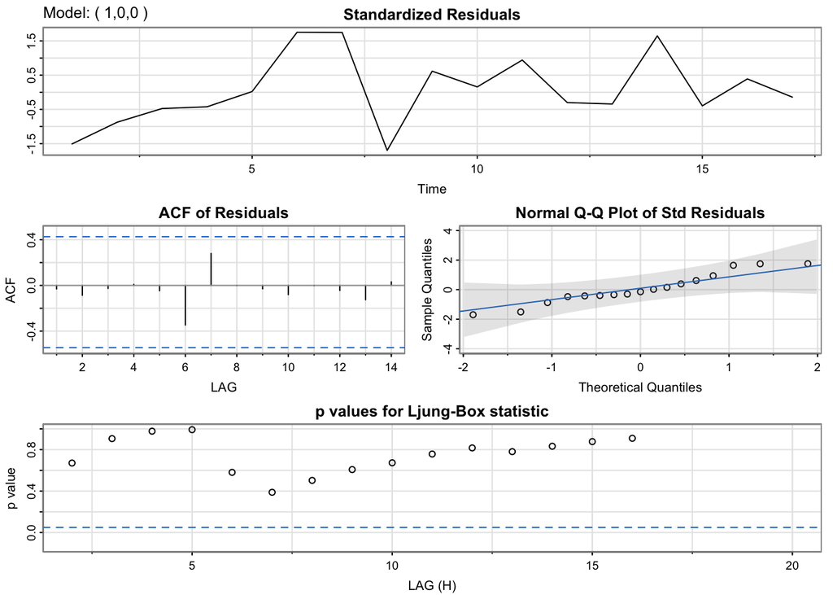

```r
# ARMA(1, 2)
ar1_ma2 <- sarima(train_pre, 1, 0, 2, P = 0, D = 0, Q = 0)
```

```
## <><><><><><><><><><><><><><>
##
## Coefficients:
##           Estimate          SE t.value p.value
## ar1         0.5352      0.7279  0.7353  0.4752
## ma1        -0.0235      0.7456 -0.0316  0.9753
## ma2        -0.0378      0.3833 -0.0985  0.9230
## xmean 6262476.1788 931110.8309  6.7258  0.0000
##
## sigma^2 estimated as 3.720567e+12 on 13 degrees of freedom
##
## AIC = 32.38828  AICc = 32.58436  BIC = 32.63334
##
```

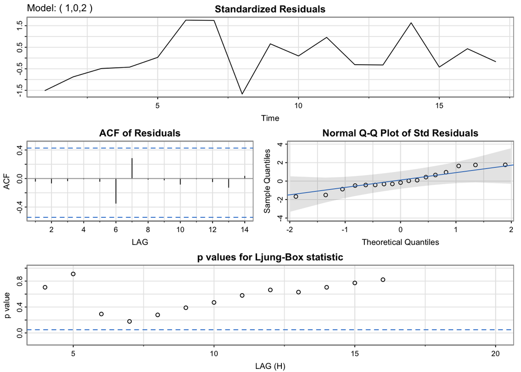

```r
# ARMA(1, 1)
ar1_ma1 <- sarima(train_pre, 1, 0, 1, P = 0, D = 0, Q = 0)
```

```
## <><><><><><><><><><><><><><>
##
## Coefficients:
##           Estimate          SE t.value p.value
## ar1         0.4734      0.4967  0.9532  0.3567
## ma1         0.0365      0.5478  0.0666  0.9478
## xmean 6277441.4932 898531.8875  6.9863  0.0000
##
## sigma^2 estimated as 3.723499e+12 on 14 degrees of freedom
##
## AIC = 32.27117  AICc = 32.37977  BIC = 32.46722
##
```

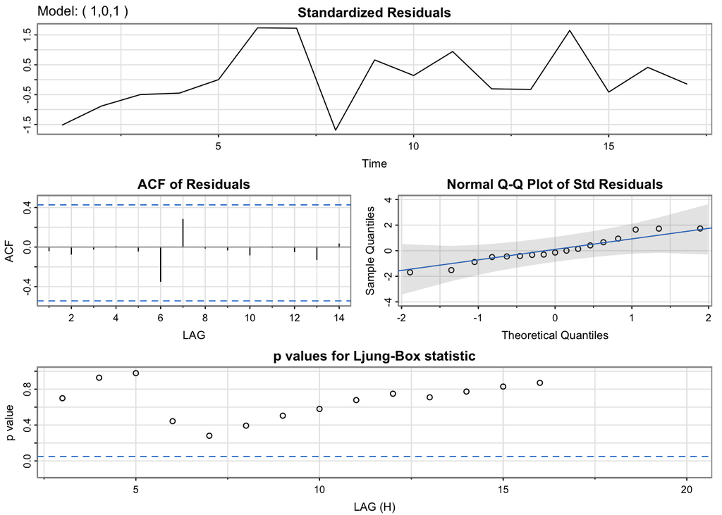

```r
# models virtually indistinguishable from eachother (AR(1) slightly
# lower AIC and BIC and has less parameters)
print(ar1$ICs)
```

```
##      AIC     AICc      BIC
## 32.15379 32.20421 32.30082
```

```r
print(ar1_ma2$ICs)
```

```
##      AIC     AICc      BIC
## 32.38828 32.58436 32.63334
```

```r
print(ar1_ma1$ICs)
```

```
##      AIC     AICc      BIC
## 32.27117 32.37977 32.46722
```

```r
# no pattern in residuals (no autocorrelation)
# standardized residuals over time still show some
```

```r
# test model on test data
#ar1_forecast <- forecast(train_pre, h = 5)
ar1_forecast <- sarima.for(ts(train_pre), n.ahead = 5, 1, 0, 0)
```

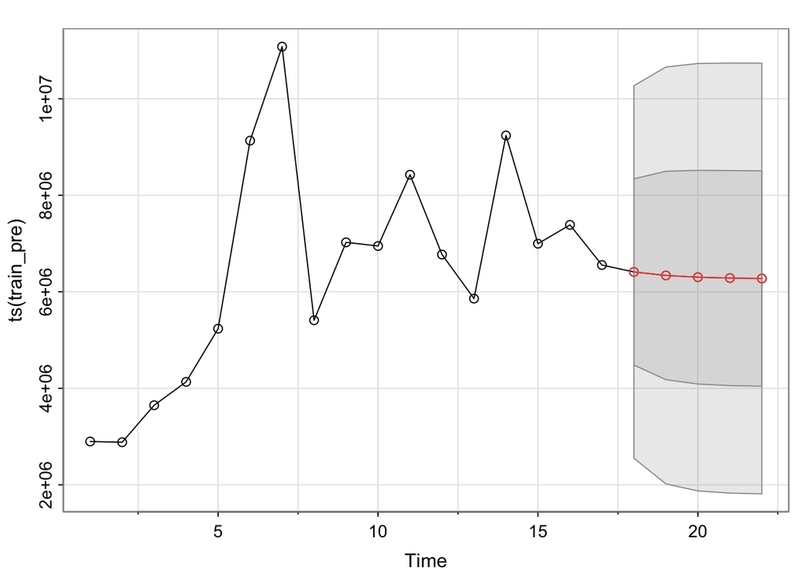

```r
ar1_pred <- ar1_forecast$pred
ar1_pred
```

```
## Time Series:
## Start = 18
## End = 22
## Frequency = 1
## [1] 6411432 6339185 6302871 6284617 6275442
```

```r
#unlist(list(pre_roa, noint_pred))

# predictions for test_pre
mape <- function(actual, prediction){
  return(mean(abs((actual - prediction)/actual)) * 100)
}
mape(test_pre, ar1_pred)
```

```
## [1] 43.59331
```

```r
# high mape makes sense - peak right after train set ends
```

## Multivariate analysis

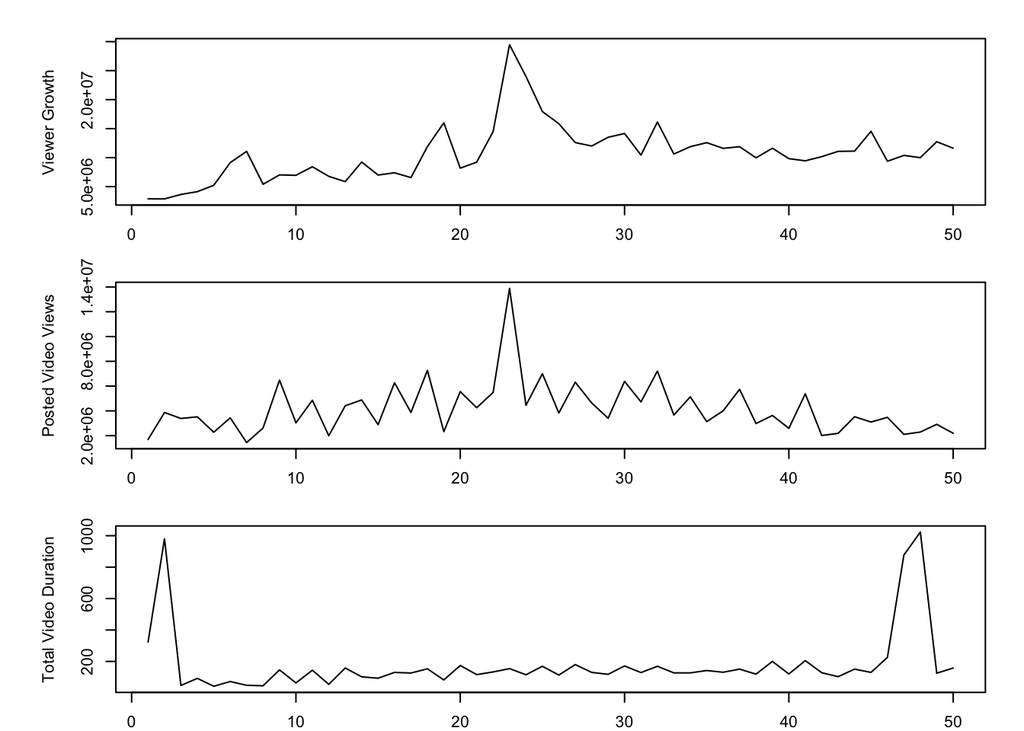

```r
par(mfrow = c(3, 1), mar = c(2, 6, 2, 2))
ts.plot(channel_growth["Viewer Growth"], xlab = "Time",
        ylab = "Viewer Growth")
ts.plot(channel_growth["Total Views of Videos Posted that Week"],
        xlab = "Time", ylab = "Posted Video Views")
ts.plot(channel_growth["Total Duration of Videos Posted that Week"],
        xlab = "Time", ylab = "Total Video Duration")
```

Sometimes, peaks in viewership do not coincide with that weeks video views and vice versa. Videos that may have performed well at the time may not have performed well in comparison to other weeks.

Videos posted during Anthony’s return have maintained the highest overall views at the time and going foreward.

Video duration consistent aside from December and January when they posted 4-9 hour themed compilations of videos from that year.

Notes:

Viewers instead of subscribers - Smosh channels old and contained many kinds of content and cast members (don’t have accurate data for those)

- Viewership based on number of new channel views in 8 day period
- Viewership from the time it was measured, but average video views recorded second week of January, so they include all views from video posted until January 2024.

8 day period instead of 7/1 week - this was based on the way videos were posted on the channel

- 45 8 day blocks (7 days inclusive)

Use viewership changes vs total views - total views don’t capture changes in viewership well (ie. 200,000 is a big jump over 8 days, but very small compared to 3mil)

- no way to know who watched what videos (and different series/video types have different audiences)

Anthony usually makes appearences on Smosh main channel and Smosh Pit.

- Pit felt more interesting to follow overtime since all the cast appears there